# 9.Model formation

# 3 steps in regression model develop

1. model formation: all candidate explanatory variables and higher order term or interaction term.
2. variable selection: compare models to determine the best model
3. model diagnostics: ##residual analysis: ##Influence statistcis:

Model formation and varibale selection

```r
sat <- read.csv('desktop/sat.txt')
```

# pairspannel plot-see relationship between variable

## raw scatterplot pairs

```r
source("desktop/pairs.panels.r")
pairs.panels(sat[,2:8])
```

[output not shown]

## log scatterplot pairs

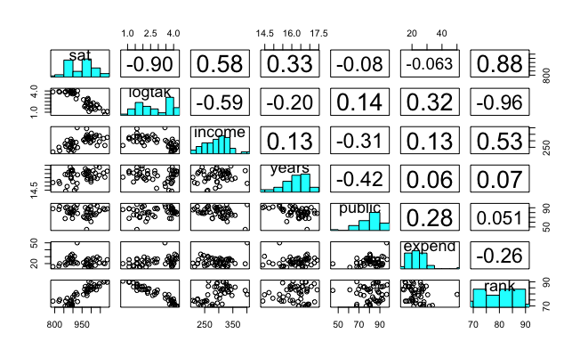

```r
sat2 <- data.frame(sat[,1:2], logtak=log(sat[,3]), sat[,4:8])
pairs.panels(sat2[,2:8])
```

# assess model fit: R-adj(big), AIG BIG Cp Press

after form model with all possible varibales, check if any variable need to be delete ## automatically check all subset model ### Cp-leaps(x,y)

```r
library(leaps)
x <- sat2[,c(4,5)]
leaps(x, sat$sat)
```

```
$which
      1     2
1  TRUE FALSE
1 FALSE  TRUE
2  TRUE  TRUE

$label
[1] "(Intercept)" "1"           "2"

$size
[1] 2 2 3

$Cp
[1]  6.129314 24.502934  3.000000
```

Cp plot-choose the one with small cp value and near y=x line

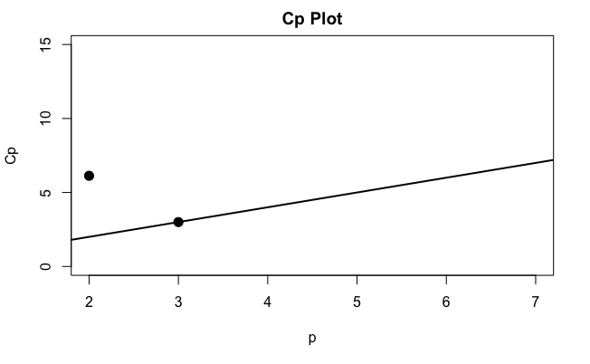

```r
mallow <- leaps(x, sat2$sat)
plot(mallow$size, mallow$Cp, main="Cp Plot", xlab="p", ylab="Cp", xlim=c(2,7), ylim=c(0,15),pch=19, cex=1.4)
abline(0,1,lwd=2)
```

### regsubsets

```r
subsets <- regsubsets(sat~income+years, data=sat2, nbest=2)
summary(subsets)
```

```
Subset selection object
Call: regsubsets.formula(sat ~ income + years, data = sat2, nbest = 2)
2 Variables  (and intercept)
       Forced in Forced out
income     FALSE      FALSE
years      FALSE      FALSE
2 subsets of each size up to 2
Selection Algorithm: exhaustive
         income years
1  ( 1 ) "*"    " "
1  ( 2 ) " "    "*"
2  ( 1 ) "*"    "*"
```

```r
summary(subsets)$cp
```

```
[1]  6.129314 24.502934  3.000000
```

```r
summary(subsets)$adjr2
```

```
[1] 0.32788453 0.09098914 0.38112475
```

```r
summary(subsets)$bic
```

```
[1] -13.07317   2.02317 -14.34014
```

#### plot of subset-according to BIC and Cp

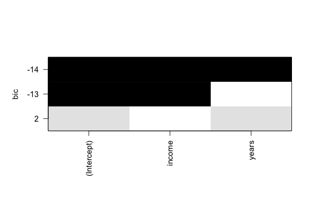

```r
plot(subsets)
```

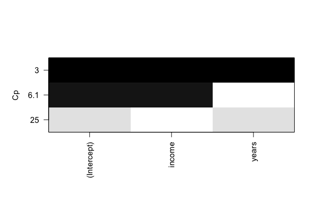

```r
plot(subsets, scale="Cp")
```

### semiauto-step-AIC BIC(no interaction)

```r
null <- lm(sat~1, data=sat2)
full <- lm(sat~.-state, data=sat2)
bwd <- step(full, direction="backward", k=2)
```

```
Start:  AIC=327.8
sat ~ (state + logtak + income + years + public + expend + rank) -
    state

         Df Sum of Sq   RSS    AIC
- public  1      25.0 26610 325.85
- income  1      47.0 26632 325.89
<none>                26585 327.80
- rank    1    1672.2 28257 328.85
- logtak  1    3589.6 30175 332.14
- years   1    4588.8 31174 333.77
- expend  1    6264.4 32850 336.38

Step:  AIC=325.85
sat ~ logtak + income + years + expend + rank

         Df Sum of Sq   RSS    AIC
- income  1      26.6 26637 323.90
<none>                26610 325.85
- rank    1    1918.1 28528 327.33
- logtak  1    4249.6 30860 331.26
- years   1    5452.8 32063 333.17
- expend  1    7430.3 34040 336.16

Step:  AIC=323.9
sat ~ logtak + years + expend + rank

         Df Sum of Sq   RSS    AIC
<none>                26637 323.90
- rank    1    2225.4 28862 325.91
- logtak  1    5071.4 31708 330.62
- years   1    5743.5 32380 331.66
- expend  1    9065.8 35703 336.55
```

#### forward elimination

```r
fwd <- step(null, scope=formula(full), direction="forward")
```

[output not shown]

#### stepwise elimination

```r
stepwise <- step(null, scope=formula(full), direction="both")
```

[output not shown]

## manually assess-same like step function

###1

```r
reg1 <- lm(sat~logtak+income+years, data=sat2)
summary(reg1)
library(MPV)
PRESS(reg1)
step(reg1, k=2)
n <- dim(sat2)[1]
step(reg1, k=log(n))
```

[output not shown]

###2 delete highest p-value income

```r
reg2 <- update(reg1,.~.-income)
```

###3 delete highest p-value….until p-value are above 5%

notion: when use update to eliminate variable, need to pay attention to hierarch, when 2nd in,can’t delete 1st order term.